# SQL Server Profiler-Script

Enrique ESCOBAR

18-12-2016

# Setup R

The best tool to do statistical analysis and graph is R (integrated in SQL Server 2016).

Use R open source programming language to support big data analytics at enterprise scale with Microsoft R Server.

# Set path and load libraries

First, load libraries needed and then the methods using those libraries.

Second, show the session information under R.

```r
# namespace
aNamespace <- "SqlServerProfiler";
#setwd("C:\\Users\\Admin\\Desktop"); #USERPROFILE
#setwd("D:/Disk_X/axon/SqlServerProfiler");
setwd("E:/Disk_X/SqlServerProfiler/");
# base lib
gDriveUtil <- paste0(c("Lib/", aNamespace, ".Util.R"), sep = "", collapse = "");
write(paste0(c("Load Util........\t", gDriveUtil), sep = "", collapse = ""), stdout());
```

```
## Load Util........    Lib/SqlServerProfiler.Util.R
```

```r
source(gDriveUtil);
```

```
## Load Util........    Lib/tibble.Util.R
## Load Util........    Lib/ggplot2.Util.R
## Load Util........    Lib/wordcloud.Util.R
## Load Util........    Lib/xlsx.Util.R
```

# Connexion & server info

## Server instance

Database Engine Instances (SQL Server) An instance of the Database Engine is a copy of the sqlservr.exe executable that runs as an operating system service. Each instance manages several system databases and one or more user databases. Each computer can run multiple instances of the Database Engine.

```r
# Server info
## Server instance
serverInstance <- XlsToDataFrameSingleRow(xlsFile = "Data/HYSEC-SQLServerInstance.xls")$SQLServerInstance;
serverInstance <- as.character(serverInstance);
serverInstance;
```

```
## [1] "DEV01-HS\\DEV"
```

## Server version

- Sql Server Version
- Sql Server Date Release
- Sql Server Copyrights and OS install

```r
# Server info
## Server version
serverVersion <- XlsToDataFrameSingleRow(xlsFile = "Data/HYSEC-SQLServerVersion.xls")$SQLServerVersion;
serverVersion <- as.character(serverVersion);
serverVersion;
```

```
## [1] "Microsoft SQL Server 2012 - 11.0.5343.0 (X64) \n\tMay  4 2015 19:11:32 \n\tCopyright (c) Microsoft Corporation\n\tStandard Edition (64-bit) on Windows NT 6.1 <X64> (Build 7601: Service Pack 1) (Hypervisor)\n"
```

## Server service

Sql Server service running on the server.

```r
# Server info
## Server service
serverService <- XlsToDataFrameSingleRow(xlsFile = "Data/HYSEC-ServiceInstance.xls")$ServiceInstance;
serverService <- as.character(serverService);
serverService;
```

```
## [1] "DEV"
```

# Server Running

Sql Server running list from start date time and number of days.

```r
serverRunning <- XlsToDataFrame("Data/HYSEC-ServerRunning_list.xls");
serverRunning$ServerName <- as.character(serverRunning$ServerName);
serverRunning$ServiceName <- as.character(serverRunning$ServiceName);
serverRunning$ServerStarted <- as.numeric(as.character(serverRunning$ServerStarted));
serverRunning$DaysRunning <- as.numeric(as.character(serverRunning$DaysRunning));
serverRunning;
```

```
## Source: local data frame [13 x 4]
##
##       ServerName ServiceName ServerStarted DaysRunning
##            <chr>       <chr>         <dbl>       <dbl>
## 1  DEV01-HS\\DEV         DEV      37719.38  4979.22469
## 2  DEV01-HS\\DEV         DEV      42674.35    24.25538
## 3  DEV01-HS\\DEV         DEV      37719.38  4979.22469
## 4  DEV01-HS\\DEV         DEV      40949.88  1748.73255
## 5  DEV01-HS\\DEV         DEV      42671.13    27.48394
## 6  DEV01-HS\\DEV         DEV      42671.13    27.48367
## 7  DEV01-HS\\DEV         DEV      42671.13    27.48154
## 8  DEV01-HS\\DEV         DEV      42671.13    27.47619
## 9  DEV01-HS\\DEV         DEV      42671.13    27.48407
## 10 DEV01-HS\\DEV         DEV      42671.13    27.47586
## 11 DEV01-HS\\DEV         DEV      41717.68   980.93108
## 12 DEV01-HS\\DEV         DEV      41722.40   976.20549
## 13 DEV01-HS\\DEV         DEV      42426.84   271.77311
```

```r
rm(serverRunning);
```

# Server Linked

List of Sql Server Linked

```r
# Server Linked
serverLinked <- XlsToDataFrame("Data/HYSEC-ServerLinked_list.xls");
serverLinked$ServerName <- as.character(serverLinked$ServerName);
serverLinked$LinkedServerID <- as.integer(as.character(serverLinked$LinkedServerID));
serverLinked$LinkedServer <- as.character(serverLinked$LinkedServer);
serverLinked$Product <- as.character(serverLinked$Product);
serverLinked$Provider <- as.character(serverLinked$Provider);
serverLinked$DataSource <- as.character(serverLinked$DataSource);
serverLinked$ModificationDate <- as.numeric(as.character(serverLinked$ModificationDate));
serverLinked$IsLinked <- as.logical(as.character(serverLinked$IsLinked));
serverLinked;
```

```
## Source: local data frame [4 x 8]
##
##      ServerName LinkedServerID  LinkedServer    Product Provider
##           <chr>          <int>         <chr>      <chr>    <chr>
## 1 DEV01-HS\\DEV              3   10.20.15.20 SQL Server  SQLNCLI
## 2 DEV01-HS\\DEV              0 DEV01-HS\\DEV SQL Server  SQLNCLI
## 3 DEV01-HS\\DEV              2      SQL01-HS SQL Server  SQLNCLI
## 4 DEV01-HS\\DEV              1      SQL02-HS SQL Server  SQLNCLI
## Variables not shown: DataSource <chr>, ModificationDate <dbl>, IsLinked
##   <lgl>.
```

```r
rm(serverLinked);
```

# Server DB

Sql Server database analysis.

## Server DB Spec

Sql Server instance database list.

```r
## Server DB spec
serverDbSpec <- XlsToDataFrame("Data/HYSEC-ServerDBSpec_list.xls");
serverDbSpec$ServerName <- as.character(serverDbSpec$ServerName);
serverDbSpec$ServiceName <- as.character(serverDbSpec$ServiceName);
serverDbSpec$DBIdentifier <- as.integer(as.character(serverDbSpec$DBIdentifier));
serverDbSpec$DBName <- as.character(serverDbSpec$DBName);
serverDbSpec$OriginalDBName <- as.character(serverDbSpec$OriginalDBName);
#
serverDbSpec$CompatiblityLevel <- as.integer(as.character(serverDbSpec$CompatiblityLevel));
serverDbSpec$DBSize <- as.numeric(as.character(serverDbSpec$DBSize));
serverDbSpec$DBGrowth <- as.numeric(as.character(serverDbSpec$DBGrowth));
serverDbSpec$IsPercentGrowth <- as.logical(as.character(serverDbSpec$IsPercentGrowth));
serverDbSpec$CreatedDate <- as.numeric(as.character(serverDbSpec$CreatedDate));
#
serverDbSpec$AutoShrink <- as.logical(as.character(serverDbSpec$AutoShrink));
#
serverDbSpec$IsAutoUpdate <- as.logical(as.character(serverDbSpec$IsAutoUpdate));
serverDbSpec$IsArithAbort <- as.logical(as.character(serverDbSpec$IsArithAbort));
serverDbSpec$PageVerifyOption <- as.character(serverDbSpec$PageVerifyOption);
serverDbSpec$Collation <- as.character(serverDbSpec$Collation);
serverDbSpec$FilePath <- as.character(serverDbSpec$FilePath);
serverDbSpec$IdSourceDB <- as.integer(as.character(serverDbSpec$IdSourceDB));
serverDbSpec;
```

```
## Source: local data frame [14 x 20]
##
##       ServerName ServiceName DBIdentifier      DBName   OriginalDBName
##            <chr>       <chr>        <int>       <chr>            <chr>
## 1  DEV01-HS\\DEV         DEV           11    ASPState         ASPState
## 2  DEV01-HS\\DEV         DEV            5    Dynamics   DYNAMICS2_Data
## 3  DEV01-HS\\DEV         DEV            9       HYLTE  GPSHYLTEDat.mdf
## 4  DEV01-HS\\DEV         DEV           10       HYSEC  GPSHYSECDat.mdf
## 5  DEV01-HS\\DEV         DEV            6 HYSEC_DELTA HYSEC_DELTA_Data
## 6  DEV01-HS\\DEV         DEV           13    HYSEC_MR         HYSEC_MR
## 7  DEV01-HS\\DEV         DEV           12   HYSEC_PDF        HYSEC_PDF
## 8  DEV01-HS\\DEV         DEV            1      master           master
## 9  DEV01-HS\\DEV         DEV            3       model         modeldev
## 10 DEV01-HS\\DEV         DEV            8      MR2012           MR2012
## 11 DEV01-HS\\DEV         DEV            8      MR2012   FILES_2C7A6696
## 12 DEV01-HS\\DEV         DEV            4        msdb         MSDBData
## 13 DEV01-HS\\DEV         DEV            7 POSTECANADA POSTECANADA_Data
## 14 DEV01-HS\\DEV         DEV            2      tempdb          tempdev
## Variables not shown: RecoveryModel <fctr>, CompatiblityLevel <int>, DBSize
##   <dbl>, DBGrowth <dbl>, IsPercentGrowth <lgl>, CreatedDate <dbl>,
##   CurrentState <fctr>, AutoShrink <lgl>, SnapshotState <fctr>,
##   IsAutoUpdate <lgl>, IsArithAbort <lgl>, PageVerifyOption <chr>,
##   Collation <chr>, FilePath <chr>, IdSourceDB <int>.
```

```r
# rm
rm(serverDbSpec);
```

## Server DB Backup

Sql Server instance database backup list.

```r
## Server DB Backup
serverDbBackup <- XlsToDataFrame("Data/HYSEC-ServerDBBackup_list.xls");
serverDbBackup$ServerName <- as.character.Date(serverDbBackup$ServerName);
serverDbBackup$ServiceName <- as.character(serverDbBackup$ServiceName);
serverDbBackup$DBName <- as.character(serverDbBackup$DBName);
serverDbBackup$Backup_finish_date <- as.numeric(as.character(serverDbBackup$Backup_finish_date));
serverDbBackup$Physical_Device_name <- as.character(serverDbBackup$Physical_Device_name);
serverDbBackup; rm(serverDbBackup);
```

```
## Source: local data frame [220 x 5]
##
##       ServerName ServiceName   DBName Backup_finish_date
##            <chr>       <chr>    <chr>              <dbl>
## 1  DEV01-HS\\DEV         DEV ASPState                 NA
## 2  DEV01-HS\\DEV         DEV Dynamics           41493.67
## 3  DEV01-HS\\DEV         DEV Dynamics           41493.67
## 4  DEV01-HS\\DEV         DEV Dynamics           41493.67
## 5  DEV01-HS\\DEV         DEV Dynamics           41493.67
## 6  DEV01-HS\\DEV         DEV Dynamics           41493.67
## 7  DEV01-HS\\DEV         DEV Dynamics           41493.67
## 8  DEV01-HS\\DEV         DEV Dynamics           41493.67
## 9  DEV01-HS\\DEV         DEV Dynamics           41499.82
## 10 DEV01-HS\\DEV         DEV Dynamics           41500.77
## ..           ...         ...      ...                ...
## Variables not shown: Physical_Device_name <chr>.
```

## Server DB Usage

Sql Server instance database usage list, including usage barplot and usage piechart.

```r
## Server DB Usage
# Server DB usage list
xlsFile <- "Data/HYSEC-Usage_list.xls";
serverDbUsageList <- XlsToDataFrame(xlsFile);
serverDbUsageList$DBIdentifier <- as.numeric(as.character(serverDbUsageList$DBIdentifier));
serverDbUsageList$DBName <- as.character(serverDbUsageList$DBName);
serverDbUsageList$DBBufferPages <- as.numeric(as.character(serverDbUsageList$DBBufferPages));
serverDbUsageList$DBBufferMB <- as.numeric(as.character(serverDbUsageList$DBBufferMB));
serverDbUsageList;
```

```
## Source: local data frame [14 x 4]
##
##    DBIdentifier      DBName DBBufferPages DBBufferMB
##           <dbl>       <chr>         <dbl>      <dbl>
## 1             9       HYLTE             2          0
## 2         32767 Resource DB            29          0
## 3             3       model             1          0
## 4            12   HYSEC_PDF             1          0
## 5             6 HYSEC_DELTA             1          0
## 6             7 POSTECANADA             1          0
## 7             1      master            14          0
## 8            10       HYSEC         95169        743
## 9             4        msdb             5          0
## 10           13    HYSEC_MR             1          0
## 11            5    Dynamics             2          0
## 12            2      tempdb           500          3
## 13           11    ASPState             1          0
## 14            8      MR2012             2          0
```

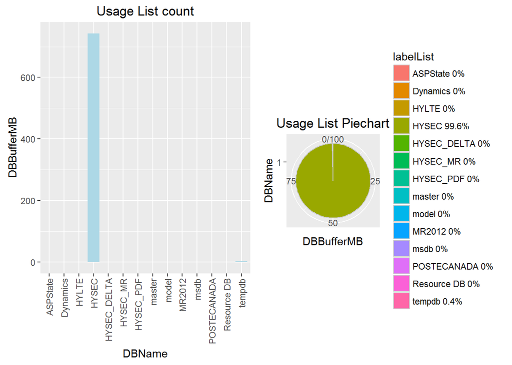

```r
# Server DB usage plots
usagePlot <- DBUsageDataFrameToBarplot(serverDbUsageList);
usagePieChart <- DBUsageDataFrameToPiechart(serverDbUsageList);
# Server DB usage plots all
grid.arrange(usagePlot, usagePieChart, nrow = 1, ncol = 2);
```

```r
# rm
rm(serverDbUsageList); rm(usagePlot); rm(usagePieChart);
## DB All parameter
# DB All parameter list
xlsFile <- "Data/HYSEC-ParametersInFuncsAndProcs.xls";
allParametersDataFrame <- XlsToDataFrame(xlsFile);
allParametersDataFrame$ObjectName <- as.character(allParametersDataFrame$ObjectName);
allParametersDataFrame$SchemaName <- as.character(allParametersDataFrame$SchemaName);
allParametersDataFrame$ObjectTypeDesc <- as.character(allParametersDataFrame$ObjectTypeDesc);
allParametersDataFrame$ParameterID <- as.integer(as.character(allParametersDataFrame$ParameterID));
allParametersDataFrame$ParameterName <- as.character(allParametersDataFrame$ParameterName);
allParametersDataFrame$ParameterType <- as.character(allParametersDataFrame$ParameterType);
allParametersDataFrame$ParameterMaxLength <- as.integer(as.character(allParametersDataFrame$ParameterMaxLength));
allParametersDataFrame$ParameterPrecision <- as.integer(as.character(allParametersDataFrame$ParameterPrecision));
allParametersDataFrame$ParamMaxBytes <- as.integer(as.character(allParametersDataFrame$ParamMaxBytes));
allParametersDataFrame$ParameterScale <- as.integer(as.character(allParametersDataFrame$ParameterScale));
allParametersDataFrame$IsParameterOutput <- as.logical(as.character(allParametersDataFrame$IsParameterOutput));
allParametersDataFrame; rm(allParametersDataFrame);
```

```
## Source: local data frame [21 x 11]
##
##           ObjectName SchemaName       ObjectTypeDesc ParameterID
##                <chr>      <chr>                <chr>       <int>
## 1             _BCPIN        dbo SQL_STORED_PROCEDURE           1
## 2             _BCPIN        dbo SQL_STORED_PROCEDURE           2
## 3             _BCPIN        dbo SQL_STORED_PROCEDURE           3
## 4  fn_diagramobjects        dbo  SQL_SCALAR_FUNCTION           0
## 5    sp_alterdiagram        dbo SQL_STORED_PROCEDURE           1
## 6    sp_alterdiagram        dbo SQL_STORED_PROCEDURE           2
## 7    sp_alterdiagram        dbo SQL_STORED_PROCEDURE           3
## 8    sp_alterdiagram        dbo SQL_STORED_PROCEDURE           4
## 9   sp_creatediagram        dbo SQL_STORED_PROCEDURE           1
## 10  sp_creatediagram        dbo SQL_STORED_PROCEDURE           2
## ..               ...        ...                  ...         ...
## Variables not shown: ParameterName <chr>, ParameterType <chr>,
##   ParameterMaxLength <int>, ParameterPrecision <int>, ParamMaxBytes <int>,
##   ParameterScale <int>, IsParameterOutput <lgl>.
```

# Screening Model

Sql Server instance database object model analysis, NA value if not available.

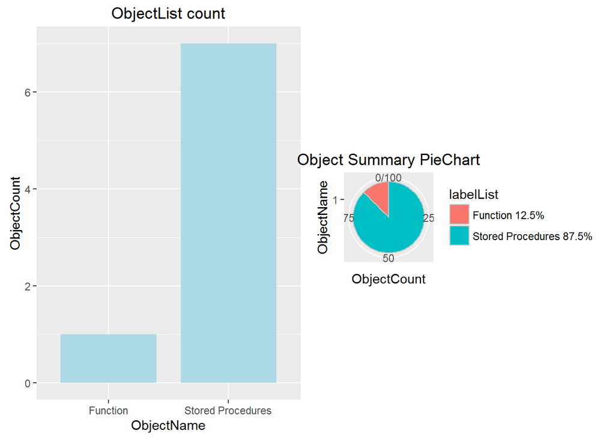

```r
## DB Object
# DB object list
xlsFile <- "Data/HYSEC-Object_list.xls";
ObjectListDataFrame <- XlsToDataFrame(xlsFile);
ObjectListDataFrame$ObjectName <- as.character(ObjectListDataFrame$ObjectName);
ObjectListDataFrame$ObjectCount <- as.integer(as.character(ObjectListDataFrame$ObjectCount));
# DB object list group fonctions
ObjectSumDataFrame <- ObjectListGroupFunctionsDataFrame(ObjectListDataFrame, "Function");
# DB object list Barplot
objectSumBarplot <- DBObjectDataFrameToBarplot(ObjectSumDataFrame);
# DB object list Piechart
objectSumPiechart <- GenericPiechartFromTwoColumnDataFrame(ObjectSumDataFrame, mainTitle = "Object Summary");
#
grid.arrange(objectSumBarplot, objectSumPiechart, nrow = 1, ncol = 2);
```

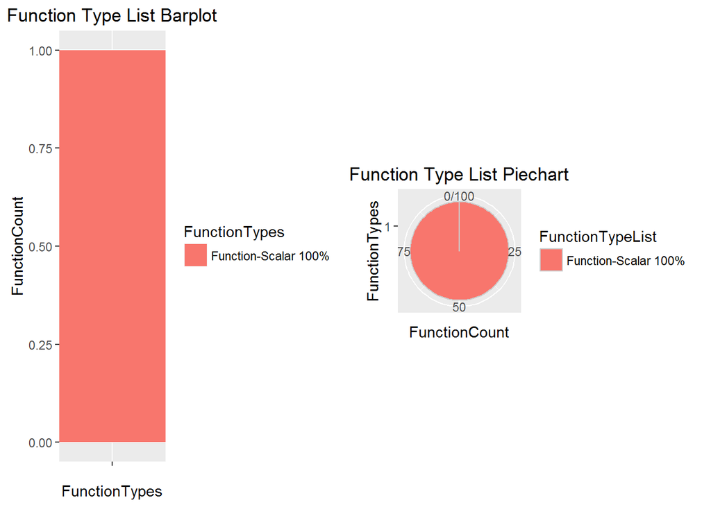

```r
# DB object list all fonctions
objectAllDataFrame <- SummarizeAllDBFunctionDataFrame(ObjectListDataFrame, "Function");
objectAllBarplot <- DBFunctionDataFrameToBarplot(objectAllDataFrame);
objectAllPiechart <- DBFunctionDataFrameToPiechart(objectAllDataFrame);
# DB object list all plot
grid.arrange(objectAllBarplot, objectAllPiechart, nrow = 1, ncol = 2);
```

```r
#
rm(xlsFile); rm(ObjectListDataFrame);
rm(ObjectSumDataFrame); rm(objectSumBarplot); rm(objectSumPiechart);
rm(objectAllDataFrame); rm(objectAllBarplot); rm(objectAllPiechart);
```

## Function Analysis

Function analysis with number count:

[output not shown]

### Function Type List

```r
## Function Analysis
# Function Analysis count
xlsFile <- "Data/HYSEC-Function_count.xls";
countFunc <- XlsToDataFrame(xlsFile);
countFunc <- as.integer(as.character(countFunc$Count));
# Function Analysis list
xlsFile <- "Data/HYSEC-Function_list.xls";
sqlDataFrame <- XlsToDataFrame(xlsFile);
sqlDataFrame$FunctionName <- as.character(sqlDataFrame$FunctionName);
sqlDataFrame$FunctionID <- as.integer(as.character(sqlDataFrame$FunctionID));
sqlDataFrame$FunctionType <- as.character(sqlDataFrame$FunctionType);
sqlDataFrame$FunctionDesc <- as.character(sqlDataFrame$FunctionDesc);
sqlDataFrame$FunctionCreated <- as.numeric(as.character(sqlDataFrame$FunctionCreated)); #
sqlDataFrame$FunctionModified <- as.numeric(as.character(sqlDataFrame$FunctionModified)); #
print(sqlDataFrame);
```

```
## Source: local data frame [328 x 6]
##
##              FunctionName FunctionID FunctionType        FunctionDesc
##                     <chr>      <int>        <chr>               <chr>
## 1       CalcPercentChange 1145054044           FN SQL_SCALAR_FUNCTION
## 2  cmIsReconciledDocument 1161054101           FN SQL_SCALAR_FUNCTION
## 3     coIsDocumentEmailed 1177054158           FN SQL_SCALAR_FUNCTION
## 4        dgppAccountIndex 1193054215           FN SQL_SCALAR_FUNCTION
## 5    dgppAcctNumberDetail 1209054272           FN SQL_SCALAR_FUNCTION
## 6          dgppAssetIndex  325575127           FN SQL_SCALAR_FUNCTION
## 7    dgppBudgetTrxSummary 1225054329           FN SQL_SCALAR_FUNCTION
## 8         dgppCheckbookID 1241054386           FN SQL_SCALAR_FUNCTION
## 9   dgppCMTransactionZoom 1257054443           FN SQL_SCALAR_FUNCTION
## 10         dgppCustomerID 1273054500           FN SQL_SCALAR_FUNCTION
## ..                    ...        ...          ...                 ...
## Variables not shown: FunctionCreated <dbl>, FunctionModified <dbl>.
```

```r
# Function Analysis list barplot
fnTypeBarplot <- DataFrameColumnToBarplot(sqlDataFrame, columnName = "FunctionType");
```

```
## Source: local data frame [3 x 2]
##
##   FunctionType List FunctionType Count
##               <chr>              <int>
## 1                FN                309
## 2                IF                  1
## 3                TF                 18
```

```r
# Function Analysis list piechart
fnTypePiechart <- DataFrameColumnToPiechart(sqlDataFrame, columnName = "FunctionType");
```

```
## Source: local data frame [3 x 2]
##
##   FunctionType List FunctionType Count
##               <chr>              <int>
## 1                FN                309
## 2                IF                  1
## 3                TF                 18
```

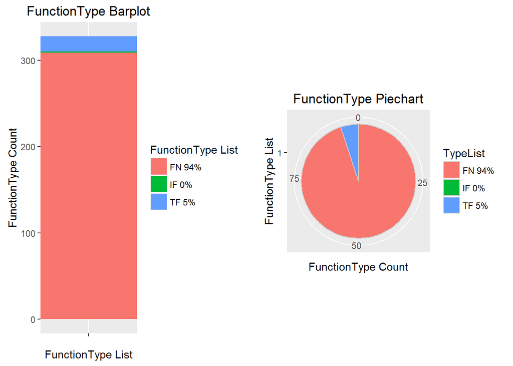

```r
#
grid.arrange(fnTypeBarplot, fnTypePiechart, nrow = 1, ncol = 2);
```

```r
# rm
rm(xlsFile); rm(sqlDataFrame); rm(fnTypeBarplot); rm(fnTypePiechart);
# Function Analysis param list
xlsFile <- "Data/HYSEC-Function_listParams.xls";
functionParamsDataFrame <- XlsToDataFrame(xlsFile);
functionParamsDataFrame$FunctionName <- as.character(functionParamsDataFrame$FunctionName);
functionParamsDataFrame$SchemaName <- as.character(functionParamsDataFrame$SchemaName);
functionParamsDataFrame$FunctionType <- as.character(functionParamsDataFrame$FunctionType);
functionParamsDataFrame$FunctionDesc <- as.character(functionParamsDataFrame$FunctionDesc);
functionParamsDataFrame$ParameterID <- as.integer(as.character(functionParamsDataFrame$ParameterID));
functionParamsDataFrame$ParameterName <- as.character(functionParamsDataFrame$ParameterName);
functionParamsDataFrame$ParameterType <- as.character(functionParamsDataFrame$ParameterType);
functionParamsDataFrame$ParamMaxLength <- as.integer(as.character(functionParamsDataFrame$ParamMaxLength));
functionParamsDataFrame$ParameterPrecision <- as.integer(as.character(functionParamsDataFrame$ParameterPrecision));
functionParamsDataFrame$ParameterScale <- as.integer(as.character(functionParamsDataFrame$ParameterScale));
functionParamsDataFrame$IsParamOutput <- as.logical(as.character(functionParamsDataFrame$IsParamOutput));
print(functionParamsDataFrame);
```

```
## Source: local data frame [1,092 x 11]
##
##              FunctionName SchemaName FunctionType        FunctionDesc
##                     <chr>      <chr>        <chr>               <chr>
## 1       CalcPercentChange        dbo           FN SQL_SCALAR_FUNCTION
## 2       CalcPercentChange        dbo           FN SQL_SCALAR_FUNCTION
## 3       CalcPercentChange        dbo           FN SQL_SCALAR_FUNCTION
## 4  cmIsReconciledDocument        dbo           FN SQL_SCALAR_FUNCTION
## 5  cmIsReconciledDocument        dbo           FN SQL_SCALAR_FUNCTION
## 6  cmIsReconciledDocument        dbo           FN SQL_SCALAR_FUNCTION
## 7  cmIsReconciledDocument        dbo           FN SQL_SCALAR_FUNCTION
## 8  cmIsReconciledDocument        dbo           FN SQL_SCALAR_FUNCTION
## 9  cmIsReconciledDocument        dbo           FN SQL_SCALAR_FUNCTION
## 10    coIsDocumentEmailed        dbo           FN SQL_SCALAR_FUNCTION
## ..                    ...        ...          ...                 ...
## Variables not shown: ParameterID <int>, ParameterName <chr>, ParameterType
##   <chr>, ParamMaxLength <int>, ParameterPrecision <int>, ParameterScale
##   <int>, IsParamOutput <lgl>.
```

```r
fnParamsDataFrameSlim <- DataFrameFromColumns(functionParamsDataFrame,
                                              "FunctionName",
                                              "FunctionType",
                                              "FunctionDesc");
print(fnParamsDataFrameSlim);
```

```
## Source: local data frame [1,092 x 3]
##
##              FunctionName FunctionType        FunctionDesc
##                     <chr>        <chr>               <chr>
## 1       CalcPercentChange           FN SQL_SCALAR_FUNCTION
## 2       CalcPercentChange           FN SQL_SCALAR_FUNCTION
## 3       CalcPercentChange           FN SQL_SCALAR_FUNCTION
## 4  cmIsReconciledDocument           FN SQL_SCALAR_FUNCTION
## 5  cmIsReconciledDocument           FN SQL_SCALAR_FUNCTION
## 6  cmIsReconciledDocument           FN SQL_SCALAR_FUNCTION
## 7  cmIsReconciledDocument           FN SQL_SCALAR_FUNCTION
## 8  cmIsReconciledDocument           FN SQL_SCALAR_FUNCTION
## 9  cmIsReconciledDocument           FN SQL_SCALAR_FUNCTION
## 10    coIsDocumentEmailed           FN SQL_SCALAR_FUNCTION
## ..                    ...          ...                 ...
```

```r
# Function Analysis repeat count
fnParamsDataFrameFat <- aggregate(list(NbParameters = rep(1, nrow(fnParamsDataFrameSlim))),
                                  fnParamsDataFrameSlim,
                                  length);
fnParamsDataFrameFat <- tibble::as_data_frame(fnParamsDataFrameFat);
write(summary(rev(fnParamsDataFrameFat)[1]), stdout());
```

```
## Min.   : 1.000
## 1st Qu.: 2.000
## Median : 2.000
## Mean   : 3.329
## 3rd Qu.: 4.000
## Max.   :20.000
```

```r
# Function Analysis without params
countFuncWith <- nrow(fnParamsDataFrameFat);
# Function Analysis without params
countFuncWithout <- countFunc - countFuncWith;
# Function Analysis barplot
OutputType <- "Fn";
# Function Analysis data frame params
fnParamsDF <- DataFrameWithoutWithTotal(countFuncWithout,
                                        countFuncWith,
                                        countFunc,
                                        OutputType);
# Function Analysis param list export
print(fnParamsDF);
```

```
## Source: local data frame [1 x 3]
##
##   FnWithoutParameters FnWithParameters FnTotal
##                 <int>            <int>   <int>
## 1                   0              328     328
```

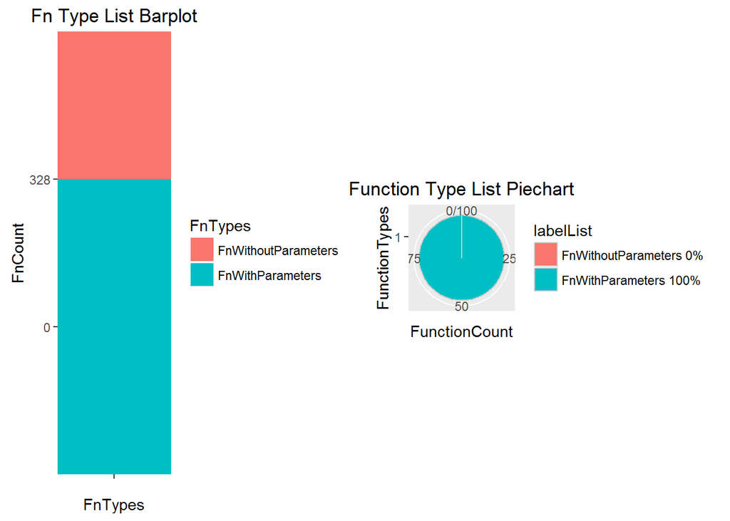

```r
# Function Analysis barplot
fnParamsBarplot <- FunctionWithoutWithTotalDFToBarplot(fnParamsDF, OutputType);
# Function Analysis piechart
fnParamsPiechart <- FunctionWithoutWithTotalDFToPiechart(fnParamsDF, OutputType = "Function");
#
grid.arrange(fnParamsBarplot, fnParamsPiechart, nrow = 1, ncol = 2);
```

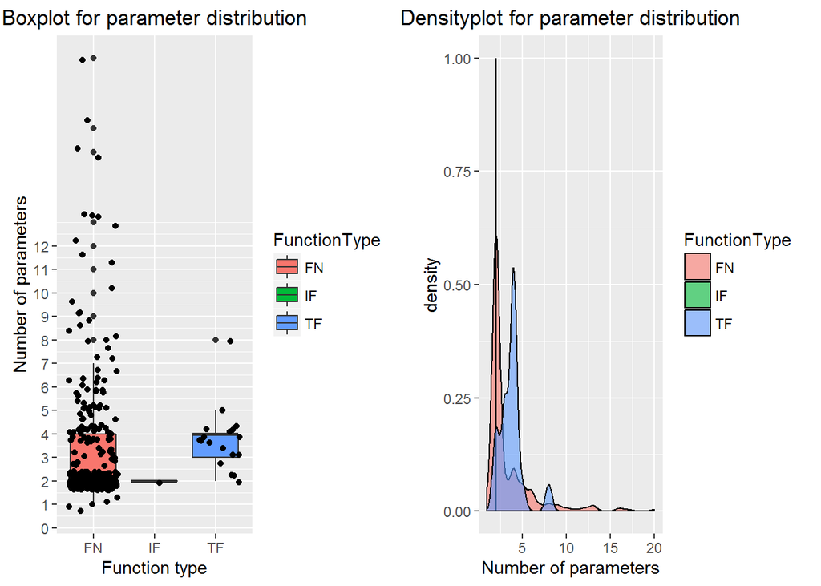

```r
# Function Analysis boxplot
fnParamsBoxplot <- DBFunctionDataFrameToBoxplot(fnParamsDataFrameFat);
# Function Analysis density plot
fnParamsDensityplot <- DBFunctionDataFrameToDensityplot(fnParamsDataFrameFat);
#
grid.arrange(fnParamsBoxplot, fnParamsDensityplot, nrow = 1, ncol = 2);
```

```r
# rm()
rm(xlsFile); rm(countFunc);
rm(functionParamsDataFrame); rm(fnParamsDataFrameSlim); rm(fnParamsDataFrameFat);
rm(countFuncWith); rm(countFuncWithout); rm(OutputType);
rm(fnParamsDF); rm(fnParamsBarplot); rm(fnParamsPiechart);
rm(fnParamsBoxplot); rm(fnParamsDensityplot);
```

## Procedure Analysis

```r
## DB StoredProc
# DB StoreProc count
xlsFile <- "Data/HYSEC-Procedure_count.xls";
countStoreProc <- XlsToDataFrameSingleRow(xlsFile)$Count;
countStoreProc <- as.integer(as.character(countStoreProc));
# DB StoreProc list
xlsFile <- "Data/HYSEC-Procedure_list.xls";
sqlDataFrame <- XlsToDataFrame(xlsFile);
sqlDataFrame$ProcedureName <- as.character(sqlDataFrame$ProcedureName);
sqlDataFrame$ProcedureID <- as.integer(as.character(sqlDataFrame$ProcedureID));
sqlDataFrame$ProcedureType <- as.character(sqlDataFrame$ProcedureType);
sqlDataFrame$ProcedureDesc <- as.character(sqlDataFrame$ProcedureDesc);
sqlDataFrame$ProcedureCreated <- as.character(sqlDataFrame$ProcedureCreated);
sqlDataFrame$ProcedureModified <- as.character(sqlDataFrame$ProcedureModified);
sqlDataFrame$IsProcedureMSShipped <- as.logical(as.character(sqlDataFrame$IsProcedureMSShipped));
sqlDataFrame; rm(sqlDataFrame);
```

```
## Source: local data frame [17,226 x 7]
##
##               ProcedureName ProcedureID ProcedureType        ProcedureDesc
##                       <chr>       <int>         <chr>                <chr>
## 1                    _BCPIN  1834697834            P  SQL_STORED_PROCEDURE
## 2      aagCreateSubWorkDist  1174294172            P  SQL_STORED_PROCEDURE
## 3    aagIsInitialiseSubWork  1190294229            P  SQL_STORED_PROCEDURE
## 4  aagRenumberAASubDistsALL  1206294286            P  SQL_STORED_PROCEDURE
## 5        aagSubAssignUpdate  1222294343            P  SQL_STORED_PROCEDURE
## 6    aagSubLedgerDistDelete  1238294400            P  SQL_STORED_PROCEDURE
## 7      aagSubWorkCodeUpdate  1254294457            P  SQL_STORED_PROCEDURE
## 8      aagSubWorkDistUpdate  1270294514            P  SQL_STORED_PROCEDURE
## 9       aagSubWorkHdrUpdate  1286294571            P  SQL_STORED_PROCEDURE
## 10              amAutoGrant   802503450            P  SQL_STORED_PROCEDURE
## ..                      ...         ...           ...                  ...
## Variables not shown: ProcedureCreated <chr>, ProcedureModified <chr>,
##   IsProcedureMSShipped <lgl>.
```

```r
# DB StoreProc param list
xlsFile <- "Data/HYSEC-Procedure_listParams.xls";
storedProcParamDataFrame <- XlsToDataFrame(xlsFile);
storedProcParamDataFrame$ProcedureName <- as.character(storedProcParamDataFrame$ProcedureName);
storedProcParamDataFrame$SchemaName <- as.character(storedProcParamDataFrame$SchemaName);
storedProcParamDataFrame$ParameterType <- as.character(storedProcParamDataFrame$ProcedureType);
storedProcParamDataFrame$ProcedureDesc <- as.character(storedProcParamDataFrame$ProcedureDesc);
storedProcParamDataFrame$ParameterID <- as.integer(as.character(storedProcParamDataFrame$ParameterID));
storedProcParamDataFrame$ParameterName <- as.character(storedProcParamDataFrame$ParameterName);
storedProcParamDataFrame$ParameterType <- as.character(storedProcParamDataFrame$ParameterType);
storedProcParamDataFrame$ParamMaxLength <- as.integer(as.character(storedProcParamDataFrame$ParamMaxLength));
storedProcParamDataFrame$ParameterPrecision <- as.integer(as.character(storedProcParamDataFrame$ParameterPrecision));
storedProcParamDataFrame$ParameterScale <- as.integer(as.character(storedProcParamDataFrame$ParameterScale));
storedProcParamDataFrame$IsParamOutput <- as.logical(as.character(storedProcParamDataFrame$IsParamOutput));
storedProcParamDataFrameSlim <- DataFrameFromColumns(storedProcParamDataFrame,
                                                     "ProcedureName",
                                                     "ProcedureType",
                                                     "ProcedureDesc");
# DB StoreProc repeat count
storedProcParamDataFrameFat <- aggregate(list(NbParameters = rep(1, nrow(storedProcParamDataFrameSlim))),
                                         storedProcParamDataFrameSlim,
                                         length);
storedProcParamDataFrameFat <- tibble::as_data_frame(storedProcParamDataFrameFat);
write(summary(rev(storedProcParamDataFrameFat)[1]), stdout());
```

```
## Min.   :  1.000
## 1st Qu.:  3.000
## Median :  5.000
## Mean   :  8.968
## 3rd Qu.: 10.000
## Max.   :204.000
```

```r
# DB StoreProc with params
countStoreProcWith <- nrow(storedProcParamDataFrameFat);
# DB StoreProc without params
countStoreProcWithout <- countStoreProc - countStoreProcWith;
# DB StoreProc data frame params
storeProcParamsDF <- DataFrameWithoutWithTotal(countStoreProcWithout,
                                               countStoreProcWith,
                                               countStoreProc,
                                               "StoreProc");
# DB StoreProc param list export
storeProcParamsDF;
```

```
## Source: local data frame [1 x 3]
##
##   StoreProcWithoutParameters StoreProcWithParameters StoreProcTotal
##                        <int>                   <int>          <int>
## 1                       9918                    7308          17226
```

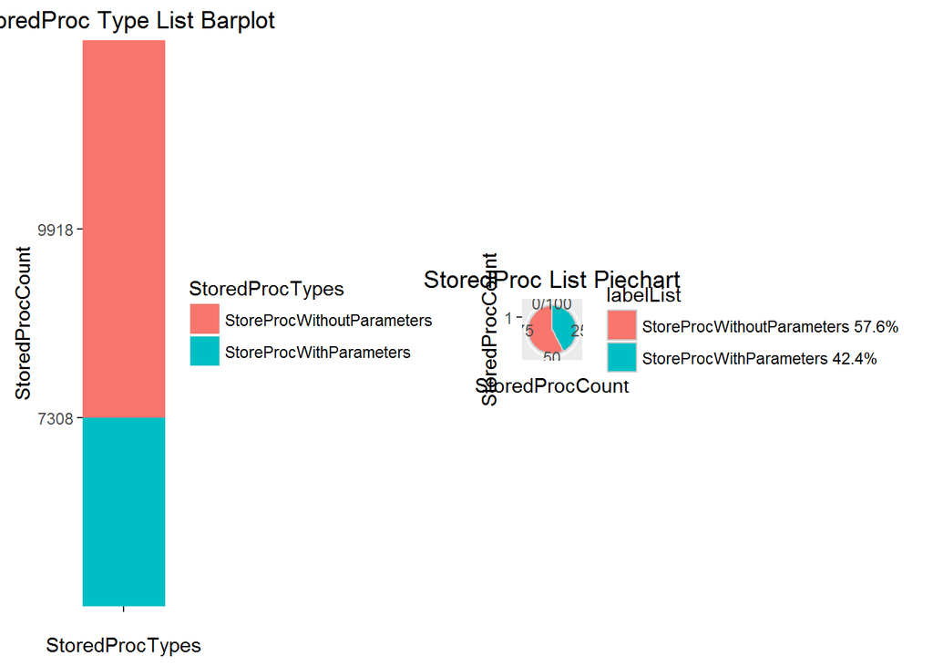

```r
# DB StoreProc barplot
OutputType <- "StoredProc";
# DB StoreProc barplot
storeProcParamsBarplot <- StoredProcWithoutWithTotalDFToBarplot(storeProcParamsDF, OutputType);
# DB StoreProc piechart
storeProcParamsPiechart <- StoredProcWithoutWithTotalDFToPiechart(storeProcParamsDF, OutputType);
#
grid.arrange(storeProcParamsBarplot, storeProcParamsPiechart, nrow = 1, ncol = 2);
```

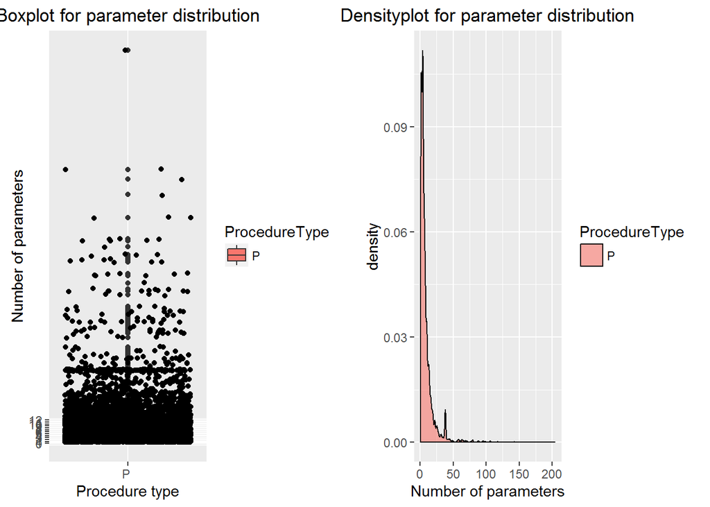

```r
# DB StoreProc boxplot
storeProcParamsBoxplot <- DBStoreProcDataFrameToBoxplot(storedProcParamDataFrameFat);
# DB StoreProc density plot
storeProcParamsDensityplot <- DBStoreProcDataFrameToDensityplot(storedProcParamDataFrameFat);
#
grid.arrange(storeProcParamsBoxplot, storeProcParamsDensityplot, nrow = 1, ncol = 2);
```

```r
# rm
rm(storedProcParamDataFrame); rm(storedProcParamDataFrameFat); rm(countStoreProc); rm(countStoreProcWith);
rm(countStoreProcWithout); rm(storeProcParamsDF); rm(OutputType); rm(storeProcParamsBarplot);
rm(storeProcParamsPiechart); rm(storeProcParamsBoxplot); rm(storeProcParamsDensityplot);
```

## DB Analysis

```r
# DB Table Count CSV
xlsFile <- "Data/HYSEC-RowCount_list.xls";
tableRowCountDataFrame <- XlsToDataFrame(xlsFile);
tableRowCountDataFrame$TableName <- as.character(tableRowCountDataFrame$TableName);
tableRowCountDataFrame$TableRows <- as.integer(as.character(tableRowCountDataFrame$TableRows));
print(tableRowCountDataFrame);
```

```
## Source: local data frame [2,265 x 2]
##
##                               TableName TableRows
##                                   <chr>     <int>
## 1        [dbo].[HS_AgeDesComptes_Histo] 217876103
## 2                       [dbo].[GL30000] 105648868
## 3                       [dbo].[RM30301] 103309230
## 4  [dbo].[GMP_ETAT_COMPTE_Detail_HISTO]  58623030
## 5        [dbo].[GMP_ETAT_COMPTE_Detail]  45341850
## 6                       [dbo].[TX30000]  42490461
## 7                       [dbo].[RM00104]  41605148
## 8                       [dbo].[RM00401]  38824825
## 9                       [dbo].[RM30601]  36694983
## 10                      [dbo].[RM30101]  33300448
## ..                                  ...       ...
```

```r
# DB Table Count repeats
tableRowCountDataFrame <- aggregate(list(RowRepeats = rep(1, nrow(tableRowCountDataFrame[-1]))),
                                    tableRowCountDataFrame[-1],
                                    length);
tableRowCountDataFrame <- tibble::as_data_frame(tableRowCountDataFrame);
print(tableRowCountDataFrame);
```

```
## Source: local data frame [824 x 2]
##
##    TableRows RowRepeats
##        <int>      <int>
## 1          0       1033
## 2          1         68
## 3          2         29
## 4          3         24
## 5          4         23
## 6          5         19
## 7          6         15
## 8          7         19
## 9          8         13
## 10         9         13
## ..       ...        ...
```

```r
# DB Table Count half > mean repeats
aMean <- mean(tableRowCountDataFrame$RowRepeats);
tableRowCountDataFrame <- subset(tableRowCountDataFrame, RowRepeats > aMean);
print(tableRowCountDataFrame);
```

```
## Source: local data frame [42 x 2]
##
##    TableRows RowRepeats
##        <int>      <int>
## 1          0       1033
## 2          1         68
## 3          2         29
## 4          3         24
## 5          4         23
## 6          5         19
## 7          6         15
## 8          7         19
## 9          8         13
## 10         9         13
## ..       ...        ...
```

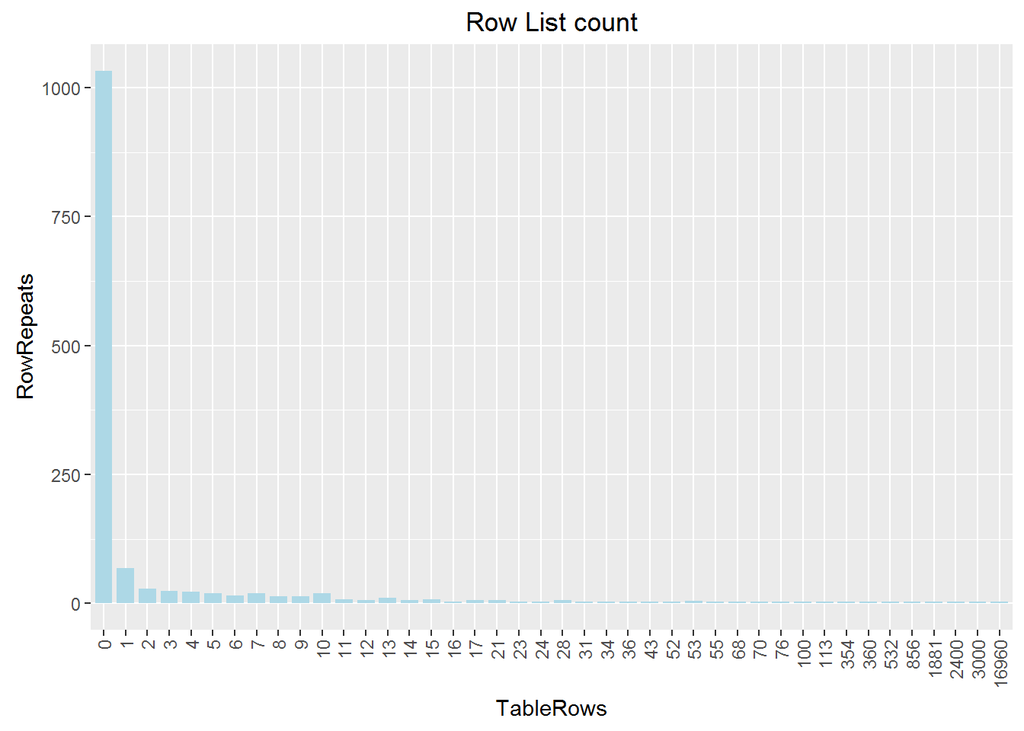

```r
# DB Table Count barplot
tableRowCountBarplot <- DBRowCountFrameToBarplot(tableRowCountDataFrame);
tableRowCountBarplot;
```

```r
# rm()
rm(xlsFile); rm(tableRowCountDataFrame); rm(aMean);  rm(tableRowCountBarplot);
```

## Table Analysis

```r
## DB Table Analysis
# DB Table Analysis count
xlsFile <- "Data/HYSEC-Table_count.xls";
countTable <- XlsToDataFrame(xlsFile);
print(paste0("Table Analysis count: ", countTable$Count));
```

```
## [1] "Table Analysis count: 2266"
```

```r
# rm()
rm(xlsFile); rm(countTable);
# DB Table Analysis list
xlsFile <- "Data/HYSEC-Table_list.xls";
sqlDataFrame <- XlsToDataFrame(xlsFile);
sqlDataFrame$TableName <- as.character(sqlDataFrame$TableName);
sqlDataFrame$TableID <- as.integer(as.character(sqlDataFrame$TableID));
sqlDataFrame$TableType <- as.character(sqlDataFrame$TableType);
sqlDataFrame$TableDesc <- as.character(sqlDataFrame$TableDesc);
sqlDataFrame$TableCreated <- as.numeric(as.character(sqlDataFrame$TableCreated)); #
sqlDataFrame$TableModified <- as.numeric(as.character(sqlDataFrame$TableModified)); #
sqlDataFrame$MaxColumnIDUsed <- as.integer(as.character(sqlDataFrame$MaxColumnIDUsed));
sqlDataFrame$IsUsingANSINulls <- as.logical(as.character(sqlDataFrame$IsUsingANSINulls));
sqlDataFrame$LOBDataSpaceID <- as.integer(as.character(sqlDataFrame$LOBDataSpaceID));
print(sqlDataFrame);
```

```
## Source: local data frame [2,266 x 9]
##
##              TableName    TableID TableType  TableDesc TableCreated
##                  <chr>      <int>     <chr>      <chr>        <dbl>
## 1             AA_APPEL 1977370409        U  USER_TABLE     39784.66
## 2  AAAATbl_FicheClient 1488320662        U  USER_TABLE     39702.62
## 3       ABSCISSEPOSTAL  342461190        U  USER_TABLE     39897.37
## 4             ACColumn 1541788750        U  USER_TABLE     39522.03
## 5        Adresse_DELTA   14219401        U  USER_TABLE     39601.64
## 6       AdresseService 1244843797        U  USER_TABLE     39729.65
## 7              AF00100  989402744        U  USER_TABLE     39477.50
## 8              AF10000  133575514        U  USER_TABLE     39477.49
## 9              AF40100  165575628        U  USER_TABLE     39477.49
## 10             AF40101  197575742        U  USER_TABLE     39477.49
## ..                 ...        ...       ...        ...          ...
## Variables not shown: TableModified <dbl>, MaxColumnIDUsed <int>,
##   IsUsingANSINulls <lgl>, LOBDataSpaceID <int>.
```

```r
# rm()
rm(xlsFile); rm(sqlDataFrame);
```

### Table Independent List

Verify if empty or not used.

```r
# DB Table Analysis Independent
xlsFile <- "Data/HYSEC-TableIndependent_list.xls";
sqlDataFrame <- XlsToDataFrame(xlsFile);
sqlDataFrame$TableWoParentWoDependents <- as.character(sqlDataFrame$TableWoParentWoDependents);
sqlDataFrame$TableID <- as.integer(as.character(sqlDataFrame$TableID));
sqlDataFrame$TableType <- as.character(sqlDataFrame$TableType);
sqlDataFrame$TableDesc <- as.character(sqlDataFrame$TableDesc);
sqlDataFrame$TableCreated <- as.numeric(as.character(sqlDataFrame$TableCreated)); #
sqlDataFrame$TableModified <- as.numeric(as.character(sqlDataFrame$TableModified)); #
sqlDataFrame$MaxColumnIDUsed <- as.integer(as.character(sqlDataFrame$MaxColumnIDUsed));
sqlDataFrame$IsUsingANSINulls <- as.logical(as.character(sqlDataFrame$IsUsingANSINulls));
sqlDataFrame$LOBDataSpaceID <- as.integer(as.character(sqlDataFrame$LOBDataSpaceID));
print(paste0("Table Independent list count: ", nrow(sqlDataFrame)));
```

```
## [1] "Table Independent list count: 2252"
```

```r
print(sqlDataFrame);
```

```
## Source: local data frame [2,252 x 9]
##
##    TableWoParentWoDependents    TableID TableType  TableDesc TableCreated
##                        <chr>      <int>     <chr>      <chr>        <dbl>
## 1                   AA_APPEL 1977370409        U  USER_TABLE     39784.66
## 2        AAAATbl_FicheClient 1488320662        U  USER_TABLE     39702.62
## 3             ABSCISSEPOSTAL  342461190        U  USER_TABLE     39897.37
## 4                   ACColumn 1541788750        U  USER_TABLE     39522.03
## 5              Adresse_DELTA   14219401        U  USER_TABLE     39601.64
## 6             AdresseService 1244843797        U  USER_TABLE     39729.65
## 7                    AF00100  989402744        U  USER_TABLE     39477.50
## 8                    AF10000  133575514        U  USER_TABLE     39477.49
## 9                    AF40100  165575628        U  USER_TABLE     39477.49
## 10                   AF40101  197575742        U  USER_TABLE     39477.49
## ..                       ...        ...       ...        ...          ...
## Variables not shown: TableModified <dbl>, MaxColumnIDUsed <int>,
##   IsUsingANSINulls <lgl>, LOBDataSpaceID <int>.
```

```r
# rm()
rm(xlsFile); rm(sqlDataFrame);
```

### Table Trunk List

Verify if empty or not used. Verify if FK point to indexed columns. Verify if PK is indexed.

```r
# DB Table Analysis Trunk
xlsFile <- "Data/HYSEC-TableTrunk_list.xls";
sqlDataFrame <- XlsToDataFrame(xlsFile);
sqlDataFrame$TableLeafName <- as.character(sqlDataFrame$TableTrunkName);
print(paste0("Table Trunk list count: ", nrow(sqlDataFrame)));
```

```
## [1] "Table Trunk list count: 7"
```

```r
print(sqlDataFrame);
```

```
## Source: local data frame [7 x 2]
##
##             TableTrunkName            TableLeafName
##                     <fctr>                    <chr>
## 1 GMP_ETAT_COMPTE_Sommaire GMP_ETAT_COMPTE_Sommaire
## 2              GMP_USAGERS              GMP_USAGERS
## 3        HS_PortailMessage        HS_PortailMessage
## 4      HS_PortailQuestions      HS_PortailQuestions
## 5      HS_PortailTypeModif      HS_PortailTypeModif
## 6           HS_ScriptGroup           HS_ScriptGroup
## 7                  RM00101                  RM00101
```

```r
# rm()
rm(xlsFile); rm(sqlDataFrame);
```

### Table Leaf List

Verify if empty or not used. Verify if FK point to indexed columns. Verify if PK is indexed.

```r
# DB Table Analysis Leaf
xlsFile <- "Data/HYSEC-TableLeaf_list.xls";
sqlDataFrame <- XlsToDataFrame(xlsFile);
sqlDataFrame$TableWoParentWoDependents <- as.character(sqlDataFrame$TableLeafName);
print(paste0("Table Leaf list count: ", nrow(sqlDataFrame)));
```

```
## [1] "Table Leaf list count: 7"
```

```r
print(sqlDataFrame);
```

```
## Source: local data frame [7 x 2]
##
##                   TableLeafName     TableWoParentWoDependents
##                          <fctr>                         <chr>
## 1               GMP_AUTO_SCRIPT               GMP_AUTO_SCRIPT
## 2        GMP_ETAT_COMPTE_Detail        GMP_ETAT_COMPTE_Detail
## 3   HS_Client_HS_PortailMessage   HS_Client_HS_PortailMessage
## 4 HS_Client_HS_PortailQuestions HS_Client_HS_PortailQuestions
## 5      HS_COMMUNICATION_USAGERS      HS_COMMUNICATION_USAGERS
## 6            HS_PortailModifLog            HS_PortailModifLog
## 7                       RM00105                       RM00105
```

```r
# rm()
rm(xlsFile); rm(sqlDataFrame);
```

### Table Parent List

Verify if empty or not used. Verify if PK is indexed.

```r
# DB Table Analysis Parent
xlsFile <- "Data/HYSEC-TableParent_list.xls";
sqlDataFrame <- XlsToDataFrame(xlsFile);
sqlDataFrame$TableParent <- as.character(sqlDataFrame$TableParent);
sqlDataFrame$TableChild <- as.character(sqlDataFrame$TableChild);
sqlDataFrame$FKName <- as.character(sqlDataFrame$FKName);
print(paste0("Table Parent list count: ", nrow(sqlDataFrame)));
```

```
## [1] "Table Parent list count: 7"
```

```r
print(sqlDataFrame);
```

```
## Source: local data frame [7 x 3]
##
##                TableParent                    TableChild
##                      <chr>                         <chr>
## 1 GMP_ETAT_COMPTE_Sommaire        GMP_ETAT_COMPTE_Detail
## 2              GMP_USAGERS      HS_COMMUNICATION_USAGERS
## 3        HS_PortailMessage   HS_Client_HS_PortailMessage
## 4      HS_PortailQuestions HS_Client_HS_PortailQuestions
## 5      HS_PortailTypeModif            HS_PortailModifLog
## 6           HS_ScriptGroup               GMP_AUTO_SCRIPT
## 7                  RM00101                       RM00105
## Variables not shown: FKName <chr>.
```

```r
# rm()
rm(xlsFile); rm(sqlDataFrame);
```

### Table Key List

Verify if FK point to indexed columns. Verify if PK is indexed.

```r
# DB Table Analysis keys list
xlsFile <- "Data/HYSEC-Table_listKeys.xls";
sqlDataFrame <- XlsToDataFrame(xlsFile);
sqlDataFrame$TableName <- as.character(sqlDataFrame$TableName);
sqlDataFrame$PKName <- as.character(sqlDataFrame$PKName);
sqlDataFrame$FKName <- as.character(sqlDataFrame$FKName);
sqlDataFrame$ColumnName <- as.character(sqlDataFrame$ColumnName);
print(paste0("Table Key list count: ", nrow(sqlDataFrame)));
```

```
## [1] "Table Key list count: 3357"
```

```r
print(sqlDataFrame);
```

```
## Source: local data frame [3,357 x 4]
##
##    TableName     PKName FKName ColumnName
##        <chr>      <chr>  <chr>      <chr>
## 1   ACColumn PKACColumn        Columnname
## 2   ACColumn PKACColumn         Tablename
## 3    AF00100  PKAF00100        ACTNUMBR_1
## 4    AF00100  PKAF00100        ACTNUMBR_2
## 5    AF00100  PKAF00100        ACTNUMBR_3
## 6    AF00100  PKAF00100        ACTNUMBR_4
## 7    AF00100  PKAF00100        ACTNUMBR_5
## 8    AF00100  PKAF00100        ACTNUMBR_6
## 9    AF00100  PKAF00100          SUBSUDID
## 10   AF10000  PKAF10000         SEQUENCE1
## ..       ...        ...    ...        ...
```

```r
# rm()
rm(xlsFile); rm(sqlDataFrame);
```

## View Analysis

Check if they are indexable or indexed, index them if needed to increase performance.

```r
## View Analysis
# View Analysis count
xlsFile <- "Data/HYSEC-View_count.xls";
countView <- XlsToDataFrame(xlsFile);
countView <- as.integer(as.character(countView$Count));
# View Analysis list
xlsFile <- "Data/HYSEC-View_list.xls";
sqlDataFrame <- XlsToDataFrame(xlsFile);
sqlDataFrame$ViewName <- as.character(sqlDataFrame$ViewName);
sqlDataFrame$ViewID <- as.integer(as.character(sqlDataFrame$ViewID));
sqlDataFrame$ViewType <- as.character(sqlDataFrame$ViewType);
sqlDataFrame$ViewDesc <- as.character(sqlDataFrame$ViewDesc);
sqlDataFrame$ViewCreated <- as.numeric(as.character(sqlDataFrame$ViewCreated)); #
sqlDataFrame$ViewModified <- as.numeric(as.character(sqlDataFrame$ViewModified)); #
sqlDataFrame$IsIndexed <- as.integer(as.character(sqlDataFrame$IsIndexed));
sqlDataFrame$IsIndexable <- as.integer(as.character(sqlDataFrame$IsIndexable));
print(paste0("View list count: ", nrow(sqlDataFrame)));
```

```
## [1] "View list count: 258"
```

```r
print(sqlDataFrame);
```

```
## Source: local data frame [258 x 8]
##
##               ViewName     ViewID ViewType ViewDesc ViewCreated
##                  <chr>      <int>    <chr>    <chr>       <dbl>
## 1             Accounts 2009773146       V      VIEW    41503.92
## 2       AccountSummary 2025773203       V      VIEW    41503.92
## 3  AccountTransactions 2041773260       V      VIEW    41503.92
## 4             ASIV0001 1600007660       V      VIEW    41503.91
## 5             ASIV0002 1616007717       V      VIEW    41503.91
## 6              ATP_BOM 1632007774       V      VIEW    41503.91
## 7           ATP_BOMWIP 1648007831       V      VIEW    41503.91
## 8         ATP_IVXFR_IN  284526976       V      VIEW    41503.91
## 9        ATP_IVXFR_VIA  300527033       V      VIEW    41503.91
## 10             ATP_POP 1664007888       V      VIEW    41503.91
## ..                 ...        ...      ...      ...         ...
## Variables not shown: ViewModified <dbl>, IsIndexed <int>, IsIndexable
##   <int>.
```

```r
# rm()
rm(countView); rm(xlsFile); rm(sqlDataFrame);
```

## Principal Key Analysis

Check if all are used nor indexed.

```r
## PKey Analysis
# PKey Analysis count
xlsFile <- "Data/HYSEC-PKeys_count.xls";
countPKeys <- XlsToDataFrame(xlsFile);
countPKeys <- as.character(countPKeys$Count);
# PKey Analysis list
xlsFile <- "Data/HYSEC-PKeys_list.xls";
sqlDataFrame <- XlsToDataFrame(xlsFile);
sqlDataFrame$TableName <- as.character(sqlDataFrame$TableName);
sqlDataFrame$ColumnName <- as.character(sqlDataFrame$ColumnName);
sqlDataFrame$PrincipalKey <- as.character(sqlDataFrame$PrincipalKey);
sqlDataFrame$PrincipalKeyID <- as.integer(as.character(sqlDataFrame$PrincipalKeyID));
sqlDataFrame$PKCreated <- as.numeric(as.character(sqlDataFrame$PKCreated));
sqlDataFrame$PKModified <- as.numeric(as.character(sqlDataFrame$PKModified));
sqlDataFrame$PKOrdinal <- as.integer(as.character(sqlDataFrame$PKOrdinal));
print(paste0("PKey list count: ", nrow(sqlDataFrame)));
```

```
## [1] "PKey list count: 3357"
```

```r
print(sqlDataFrame);
```

```
## Source: local data frame [3,357 x 7]
##
##    TableName ColumnName PrincipalKey PrincipalKeyID PKCreated PKModified
##        <chr>      <chr>        <chr>          <int>     <dbl>      <dbl>
## 1   ACColumn Columnname   PKACColumn     1850697891  39522.53   39522.53
## 2   ACColumn  Tablename   PKACColumn     1850697891  39522.53   39522.53
## 3    AF00100 ACTNUMBR_1    PKAF00100      672147773  41502.85   41502.85
## 4    AF00100 ACTNUMBR_2    PKAF00100      672147773  41502.85   41502.85
## 5    AF00100 ACTNUMBR_3    PKAF00100      672147773  41502.85   41502.85
## 6    AF00100 ACTNUMBR_4    PKAF00100      672147773  41502.85   41502.85
## 7    AF00100 ACTNUMBR_5    PKAF00100      672147773  41502.85   41502.85
## 8    AF00100 ACTNUMBR_6    PKAF00100      672147773  41502.85   41502.85
## 9    AF00100   SUBSUDID    PKAF00100      672147773  41502.85   41502.85
## 10   AF10000  SEQUENCE1    PKAF10000     2083746726  39522.56   39522.56
## ..       ...        ...          ...            ...       ...        ...
## Variables not shown: PKOrdinal <int>.
```

```r
# PKey Analysis list histogram
aTable <- ColumnDataFrameToFrequencyTable(sqlDataFrame, columnName = "TableName");
aTibble <- FrequencyTableToTibble(aTable, aTitle = "PrincipalKeyTable");
```

```
## Source: local data frame [1,380 x 2]
##
##    PrincipalKeyTable List PrincipalKeyTable Count
##                     <chr>                   <int>
## 1                ACColumn                       2
## 2                 AF00100                       7
## 3                 AF10000                       1
## 4                 AF40100                       1
## 5                 AF40101                       1
## 6                 AF40102                       3
## 7                 AF40103                       2
## 8                 AF40104                       3
## 9                 AF40105                       3
## 10                AF40106                       2
## ..                    ...                     ...
```

```r
principalKeyHistogram <- TwoColumnDataFrameToHistogram(aTibble, mainTitle = "PrincipalKey per Table");
# rm
rm(countPKeys); rm(xlsFile); rm(sqlDataFrame);
rm(aTable); rm(aTibble); rm(principalKeyHistogram);
```

## Foreign Key Analysis

Check if all are used nor indexed nor trusted. Verify tables if ON Delete CASCADE.

```r
## FKey Analysis
# FKey Analysis count
xlsFile <- "Data/HYSEC-FKeys_count.xls";
countFKeys <- XlsToDataFrame(xlsFile);
countFKeys <- as.integer(as.character(countFKeys$Count));
# FKey Analysis list
xlsFile <- "Data/HYSEC-FKeys_list.xls";
sqlDataFrame <- XlsToDataFrame(xlsFile);
sqlDataFrame$TableName <- as.character(sqlDataFrame$TableName);
sqlDataFrame$ColumnName <- as.character(sqlDataFrame$ColumnName);
sqlDataFrame$ForeignKey <- as.character(sqlDataFrame$ForeignKey);
sqlDataFrame$ForeignKeyID <- as.character(sqlDataFrame$ForeignKey);
sqlDataFrame$ReferenceTableName <- as.character(sqlDataFrame$ReferenceTableName);
sqlDataFrame$ReferenceColumnName <- as.character(sqlDataFrame$ReferenceColumnName);
sqlDataFrame$FKCreated <- as.numeric(as.character(sqlDataFrame$FKCreated));
sqlDataFrame$FKModified <- as.numeric(as.character(sqlDataFrame$FKModified));
sqlDataFrame$FKnotTrusted <- as.logical(as.character(sqlDataFrame$FKnotTrusted));
sqlDataFrame$OnDelete <- as.character(sqlDataFrame$OnDelete);
sqlDataFrame$OnUpdate <- as.character(sqlDataFrame$OnUpdate);
print(paste0("FKeys list count: ", nrow(sqlDataFrame)));
```

```
## [1] "FKeys list count: 7"
```

```r
print(sqlDataFrame);
```

```
## Source: local data frame [7 x 11]
##
##                       TableName            ColumnName
##                           <chr>                 <chr>
## 1               GMP_AUTO_SCRIPT         ScriptGroupId
## 2        GMP_ETAT_COMPTE_Detail                   SID
## 3   HS_Client_HS_PortailMessage   HS_PortailMessageID
## 4 HS_Client_HS_PortailQuestions HS_PortailQuestionsID
## 5      HS_COMMUNICATION_USAGERS              UsagerID
## 6            HS_PortailModifLog HS_PortailTypeModifID
## 7                       RM00105              CPRCSTNM
## Variables not shown: ForeignKey <chr>, ForeignKeyID <chr>,
##   ReferenceTableName <chr>, ReferenceColumnName <chr>, FKCreated <dbl>,
##   FKModified <dbl>, FKnotTrusted <lgl>, OnDelete <chr>, OnUpdate <chr>.
```

```r
# FKey Analysis list histogram
aTable <- ColumnDataFrameToFrequencyTable(sqlDataFrame, columnName = "TableName");
aTibble <- FrequencyTableToTibble(aTable, aTitle = "PrincipalKeyTable");
```

```
## Source: local data frame [7 x 2]
##
##          PrincipalKeyTable List PrincipalKeyTable Count
##                           <chr>                   <int>
## 1               GMP_AUTO_SCRIPT                       1
## 2        GMP_ETAT_COMPTE_Detail                       1
## 3   HS_Client_HS_PortailMessage                       1
## 4 HS_Client_HS_PortailQuestions                       1
## 5      HS_COMMUNICATION_USAGERS                       1
## 6            HS_PortailModifLog                       1
## 7                       RM00105                       1
```

```r
fKeyHistogram <- TwoColumnDataFrameToHistogram(aTibble, mainTitle = "ForeignKey per Table");
# rm
rm(countFKeys); rm(xlsFile); rm(sqlDataFrame);
rm(aTable); rm(aTibble); rm(fKeyHistogram);
```

## Index Analysis

Indexes are created on columns in tables or views. The index provides a fast way to look up data based on the values within those columns. For example, if you create an index on the primary key and then search for a row of data based on one of the primary key values, SQL Server first finds that value in the index, and then uses the index to quickly locate the entire row of data. Without the index, a table scan would have to be performed in order to locate the row, which can have a significant effect on performance.

You can create indexes on most columns in a table or a view. The exceptions are primarily those columns configured with large object (LOB) data types, such as image, text, and varchar(max). You can also create indexes on XML columns, but those indexes are slightly different from the basic index and are beyond the scope of this article. Instead, I’ll focus on those indexes that are implemented most commonly in a SQL Server database.

### Clustered Indexes

A clustered index stores the actual data rows at the leaf level of the index. Returning to the example above, that would mean that the entire row of data associated with the primary key value of 123 would be stored in that leaf node. An important characteristic of the clustered index is that the indexed values are sorted in either ascending or descending order. As a result, there can be only one clustered index on a table or view. In addition, data in a table is sorted only if a clustered index has been defined on a table.

Note: A table that has a clustered index is referred to as a clustered table. A table that has no clustered index is referred to as a heap.

### Nonclustered Indexes

Unlike a clustered indexed, the leaf nodes of a nonclustered index contain only the values from the indexed columns and row locators that point to the actual data rows, rather than contain the data rows themselves. This means that the query engine must take an additional step in order to locate the actual data.

A row locator’s structure depends on whether it points to a clustered table or to a heap. If referencing a clustered table, the row locator points to the clustered index, using the value from the clustered index to navigate to the correct data row. If referencing a heap, the row locator points to the actual data row.

Nonclustered indexes cannot be sorted like clustered indexes; however, you can create more than one nonclustered index per table or view. SQL Server 2005 supports up to 249 nonclustered indexes, and SQL Server 2008 support up to 999. This certainly doesn’t mean you should create that many indexes. Indexes can both help and hinder performance, as I explain later in the article.

### Index List

```r
## Index Analysis
# Index Analysis count
xlsFile <- "Data/HYSEC-Index_count.xls";
countIndex <- XlsToDataFrame(xlsFile);
countIndex <- as.integer(as.character(countIndex$Count));
# Index Analysis list
xlsFile <- "Data/HYSEC-Index_list.xls";
sqlDataFrame <- XlsToDataFrame(xlsFile);
sqlDataFrame$DBName <- as.character(sqlDataFrame$DBName);
sqlDataFrame$TableName <- as.character(sqlDataFrame$TableName);
sqlDataFrame$ColumnNumber <- as.integer(as.character(sqlDataFrame$ColumnNumber));
sqlDataFrame$ColumnName <- as.character(sqlDataFrame$ColumnName);
sqlDataFrame$ConstraintName <- as.character(sqlDataFrame$ConstraintName);
sqlDataFrame$ConstraintType <- as.character(sqlDataFrame$ConstraintType);
sqlDataFrame$ConstraintDescription <- as.character(sqlDataFrame$ConstraintDescription);
sqlDataFrame$CreatedDate <- as.numeric(as.character(sqlDataFrame$CreatedDate));#
sqlDataFrame$ConstraintDefinition <- as.character(sqlDataFrame$ConstraintDefinition);
sqlDataFrame$UsesDBCollation <- as.logical(as.character(sqlDataFrame$UsesDBCollation));
sqlDataFrame$IsSystemNamed <- as.logical(as.character(sqlDataFrame$IsSystemNamed));
print(sqlDataFrame);
```

```
## Source: local data frame [2,438 x 11]
##
##    DBName TableName ColumnNumber      ColumnName
##     <chr>     <chr>        <int>           <chr>
## 1   HYSEC   BM00101            5  Effective_Date
## 2   HYSEC   BM00101            6   Obsolete_Date
## 3   HYSEC   BM00101            9        CREATDDT
## 4   HYSEC   BM00101           10         MODIFDT
## 5   HYSEC   BM00111           11  Effective_Date
## 6   HYSEC   BM00111           12   Obsolete_Date
## 7   HYSEC   BM10200            6 Completion_Date
## 8   HYSEC   BM10200            7   BM_Start_Date
## 9   HYSEC   BM10200            8         TRXDATE
## 10  HYSEC   BM10200            9        PSTGDATE
## ..    ...       ...          ...             ...
## Variables not shown: ConstraintName <chr>, ConstraintType <chr>,
##   ConstraintDescription <chr>, CreatedDate <dbl>, ConstraintDefinition
##   <chr>, UsesDBCollation <lgl>, IsSystemNamed <lgl>.
```

```r
# Index Analysis list histogram
aTable <- ColumnDataFrameToFrequencyTable(sqlDataFrame, columnName = "TableName");
aTibble <- FrequencyTableToTibble(aTable, aTitle = "IndexPerTable");
```

```
## Source: local data frame [572 x 2]
##
##    IndexPerTable List IndexPerTable Count
##                 <chr>               <int>
## 1             BM00101                   4
## 2             BM00111                   2
## 3             BM10200                   7
## 4             BM10400                   3
## 5             BM30100                   2
## 6             BM30200                   7
## 7             BM30400                   3
## 8            CAM10000                   2
## 9            CAM10100                   2
## 10           CAM10200                   4
## ..                ...                 ...
```

```r
indexesHistogram <- TwoColumnDataFrameToHistogram(aTibble, mainTitle = "Index per Table");
# rm
rm(countIndex); rm(xlsFile); rm(sqlDataFrame);
rm(aTable); rm(aTibble); rm(indexesHistogram);
# Index Analysis type list
xlsFile <- "Data/HYSEC-Index_listTypes.xls";
sqlDataFrame <- XlsToDataFrame(xlsFile);
sqlDataFrame$TableName <- as.character(sqlDataFrame$TableName);
sqlDataFrame$TableType <- as.character(sqlDataFrame$TableType);
sqlDataFrame$TableDesc <- as.character(sqlDataFrame$TableDesc);
sqlDataFrame$TableIndexID <- as.integer(as.character(sqlDataFrame$TableIndexID));
sqlDataFrame$IndexName <- as.character(sqlDataFrame$IndexName);
sqlDataFrame$IndexID <- as.integer(as.character(sqlDataFrame$IndexID)) ;
sqlDataFrame$IndexType <- as.character(sqlDataFrame$IndexType);
sqlDataFrame$ConstraintType <- as.character(sqlDataFrame$ConstraintType);
sqlDataFrame$AllocUnitID <- as.numeric(as.character(sqlDataFrame$AllocUnitID));
print(paste0("Index Type list count: ", nrow(sqlDataFrame)));
```

```
## [1] "Index Type list count: 5447"
```

```r
print(sqlDataFrame);
```

```
## Source: local data frame [5,447 x 9]
##
##                         TableName TableType      TableDesc TableIndexID
##                             <chr>     <chr>          <chr>        <int>
## 1  filestream_tombstone_608147545        IT INTERNAL_TABLE            1
## 2  filestream_tombstone_608147545        IT INTERNAL_TABLE            2
## 3    filetable_updates_1632359413        IT INTERNAL_TABLE            1
## 4       queue_messages_1303480218        IT INTERNAL_TABLE            1
## 5       queue_messages_1303480218        IT INTERNAL_TABLE            1
## 6       queue_messages_1303480218        IT INTERNAL_TABLE            1
## 7       queue_messages_1303480218        IT INTERNAL_TABLE            2
## 8       queue_messages_1335480332        IT INTERNAL_TABLE            1
## 9       queue_messages_1335480332        IT INTERNAL_TABLE            1
## 10      queue_messages_1335480332        IT INTERNAL_TABLE            1
## ..                            ...       ...            ...          ...
## Variables not shown: IndexName <chr>, IndexID <int>, IndexType <chr>,
##   ConstraintType <chr>, AllocUnitID <dbl>.
```

```r
# rm
rm(xlsFile); rm(sqlDataFrame);
```

Verify Constraint Type. Verify if can lock page.

## Constraint Analysis

Constraints let you define the way the Database Engine automatically enforces the integrity of a database. Constraints define rules regarding the values allowed in columns and are the standard mechanism for enforcing integrity. Using constraints is preferred to using DML Triggers, rules, and defaults. The query optimizer also uses constraint definitions to build high-performance query execution plans.

Validate if constraint is respected.

### Constraint Analysis List

```r
## Constraint Analysis
# Constraint Analysis List
xlsFile <- "Data/HYSEC-Constraint_list.xls";
sqlDataFrame <- XlsToDataFrame(xlsFile);
sqlDataFrame$DBName <- as.character(sqlDataFrame$DBName);
sqlDataFrame$TableName <- as.character(sqlDataFrame$TableName);
sqlDataFrame$ColumnNumber <- as.integer(as.character(sqlDataFrame$ColumnNumber));
sqlDataFrame$ColumnName <- as.character(sqlDataFrame$ColumnName);
sqlDataFrame$ConstraintName <- as.character(sqlDataFrame$ConstraintName);
sqlDataFrame$ConstraintType <- as.character(sqlDataFrame$ConstraintType);
sqlDataFrame$ConstraintDescription <- as.character(sqlDataFrame$ConstraintDescription);
#
sqlDataFrame$ConstraintDefinition <- as.character(sqlDataFrame$ConstraintDefinition);
print(paste0("Constraint list count: ", nrow(sqlDataFrame)));
```

```
## [1] "Constraint list count: 2438"
```

```r
print(sqlDataFrame);
```

```
## Source: local data frame [2,438 x 28]
##
##    DBName TableName ColumnNumber      ColumnName
##     <chr>     <chr>        <int>           <chr>
## 1   HYSEC   BM00101            5  Effective_Date
## 2   HYSEC   BM00101            6   Obsolete_Date
## 3   HYSEC   BM00101            9        CREATDDT
## 4   HYSEC   BM00101           10         MODIFDT
## 5   HYSEC   BM00111           11  Effective_Date
## 6   HYSEC   BM00111           12   Obsolete_Date
## 7   HYSEC   BM10200            6 Completion_Date
## 8   HYSEC   BM10200            7   BM_Start_Date
## 9   HYSEC   BM10200            8         TRXDATE
## 10  HYSEC   BM10200            9        PSTGDATE
## ..    ...       ...          ...             ...
## Variables not shown: ConstraintName <chr>, ConstraintType <chr>,
##   ConstraintDescription <chr>, CreatedDate <fctr>, ConstraintDefinition
##   <chr>, name <fctr>, object_id <fctr>, principal_id <fctr>, schema_id
##   <fctr>, parent_object_id <fctr>, type <fctr>, type_desc <fctr>,
##   create_date <fctr>, modify_date <fctr>, is_ms_shipped <fctr>,
##   is_published <fctr>, is_schema_published <fctr>, is_disabled <fctr>,
##   is_not_for_replication <fctr>, is_not_trusted <fctr>, parent_column_id
##   <fctr>, definition <fctr>, uses_database_collation <fctr>,
##   is_system_named <fctr>.
```

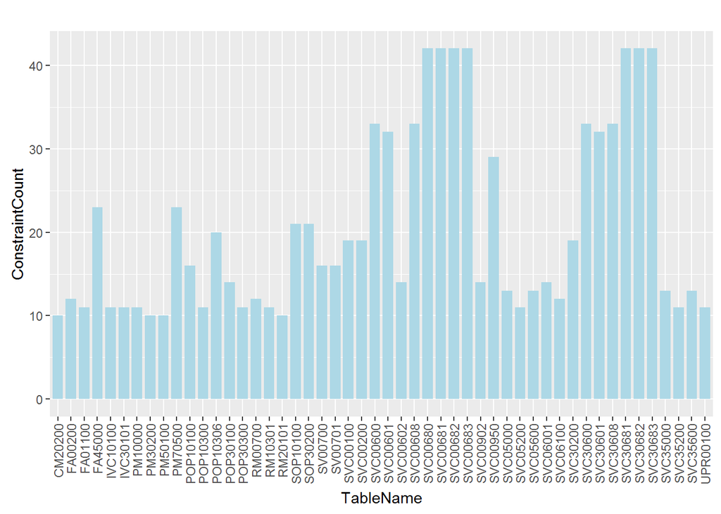

```r
sqlDataFrame <- ConstraintToTableNameFrequency(sqlDataFrame);
constraintBarplot <- TwoColumnDataFrameToBarlot(sqlDataFrame);
constraintBarplot;
```

```r
# rm()
rm(xlsFile); rm(sqlDataFrame); rm(constraintBarplot);
```

# Trigger Analysis

A trigger is a database object that is attached to a table. In many aspects it is similar to a stored procedure. Triggers are a special class of stored procedure defined to execute automatically when an UPDATE, INSERT or DELETE statement is issued against a table or view. Avoid nested triggers and recursive triggers. Creates a DML, DDL, or logon trigger. A trigger is a special kind of stored procedure that automatically executes when an event occurs in the database server. DML triggers execute when a user tries to modify data through a data manipulation language (DML) event. DML events are INSERT, UPDATE, or DELETE statements on a table or view. These triggers fire when any valid event is fired, regardless of whether or not any table rows are affected.

DDL triggers execute in response to a variety of data definition language (DDL) events. These events primarily correspond to Transact-SQL CREATE, ALTER, and DROP statements, and certain system stored procedures that perform DDL-like operations. Logon triggers fire in response to the LOGON event that is raised when a user sessions is being established. Triggers can be created directly from Transact-SQL statements or from methods of assemblies that are created in the Microsoft .NET Framework common language runtime (CLR) and uploaded to an instance of SQL Server. SQL Server allows for creating multiple triggers for any specific statement.

Triggers types are **After Triggers** and **Instead Of Triggers**.

## When to use Triggers

There are more than a handful of developers who are not real clear when triggers should be used. I only use them when I need to perform a certain action as a result of an INSERT, UPDATE or DELETE and ad hoc SQL (aka SQL Passthrough) is used. I implement most of my data manipulation code via stored procedures and when you do this the trigger functionality can be moved into the procedure. For example, let’s say you want to send an email to the Sales Manager when an order is entered whose priority is high. When ad hoc SQL is used to insert the Orders row, a trigger is used to determine the OrderPriority and send the email when the criteria is met.

## After Triggers

These triggers run after an insert, update or delete on a table. **They are not supported for views**. The CREATE TRIGGER statement is used to create the trigger. THE ON clause specifies the table name on which the trigger is to be attached. The FOR INSERT specifies that this is an AFTER INSERT trigger. In place of FOR INSERT, AFTER INSERT can be used. Both of them mean the same. They can be classified further into three types as:

- AFTER INSERT Trigger.
- AFTER UPDATE Trigger.
- AFTER DELETE Trigger.

## Instead Of Triggers

These can be used as an interceptor for anything that anyone tried to do on our table or view. If you define an *Instead Of trigger* on a table for the Delete operation, they try to delete rows, and they will not actually get deleted (unless you issue another delete instruction from within the trigger). They can be classified into three types as:

- INSTEAD OF INSERT Trigger.
- INSTEAD OF UPDATE Trigger.
- INSTEAD OF DELETE Trigger.

## Trigger Analysis list

```r
# Trigger Analysis
## Trigger Analysis List
xlsFile <- "Data/HYSEC-Trigger_list.xls";
sqlDataFrame <- XlsToDataFrame(xlsFile);
sqlDataFrame$TableName <- as.character(sqlDataFrame$TableName);
sqlDataFrame$TriggerObjectId <- as.integer(as.character(sqlDataFrame$TriggerObjectId));
sqlDataFrame$TriggerName <- as.character(sqlDataFrame$TriggerName);
sqlDataFrame$TriggerText <- as.character(sqlDataFrame$TriggerText);
sqlDataFrame$TriggerCreation <- as.numeric(as.character(sqlDataFrame$TriggerCreation));
sqlDataFrame$TriggerRefDate <- as.numeric(as.character(sqlDataFrame$TriggerRefDate));
sqlDataFrame$TriggerVersion <- as.integer(as.character(sqlDataFrame$TriggerVersion));
sqlDataFrame$TriggerType <- as.character(sqlDataFrame$TriggerType);
sqlDataFrame$ObjectType <- as.character(sqlDataFrame$ObjectType);
sqlDataFrame$TriggerDesc <- as.character(sqlDataFrame$TriggerDesc);
sqlDataFrame$IsInsteadOfTrigger <- as.logical(as.character(sqlDataFrame$IsInsteadOfTrigger));
sqlDataFrame$IsUpdate <- as.logical(as.integer(as.character(sqlDataFrame$IsUpdate)));
sqlDataFrame$IsDelete <- as.logical(as.integer(as.character(sqlDataFrame$IsDelete)));
sqlDataFrame$IsInsert <- as.logical(as.integer(as.character(sqlDataFrame$IsInsert)));
sqlDataFrame$IsAfterTrigger <- as.logical(as.integer(as.character(sqlDataFrame$IsAfterTrigger)));
### trigger group
sqlDataFrame$TriggerGroup <- "";
for(i in 1:length(sqlDataFrame$IsAfterTrigger)){
  itIs <- as.logical(sqlDataFrame$IsAfterTrigger[i]);

  if(itIs == TRUE){
    sqlDataFrame$TriggerGroup[i] <- "AfterTrigger";
  } else {
    sqlDataFrame$TriggerGroup[i] <- "InsteadOfTrigger";
  }
}
rm(i); rm(itIs) ;
### trigger subgroup
sqlDataFrame$TriggerSubgroup <- "";
for(i in 1:length(sqlDataFrame$IsAfterTrigger)){
  itIs <- as.logical(sqlDataFrame$IsAfterTrigger[i]);

  if(itIs == TRUE){
    sqlDataFrame$TriggerSubgroup[i] <- "After";
  } else {
    sqlDataFrame$TriggerSubgroup[i] <- "InsteadOf";
  }

  isUpdate <- as.logical(sqlDataFrame$IsUpdate[i]);

  if(isUpdate == TRUE){
    sqlDataFrame$TriggerSubgroup[i] <- paste0(sqlDataFrame$TriggerSubgroup[i], "Update");
  }

  isDelete <- as.logical(sqlDataFrame$IsDelete[i]);

  if(isDelete == TRUE){
    sqlDataFrame$TriggerSubgroup[i] <- paste0(sqlDataFrame$TriggerSubgroup[i], "Delete");
  }

  isInsert <- as.logical(sqlDataFrame$IsInsert[i]);

  if(isInsert == TRUE){
    sqlDataFrame$TriggerSubgroup[i] <- paste0(sqlDataFrame$TriggerSubgroup[i], "Insert");
  }
}
rm(i); rm(itIs) ;
rm(isDelete); rm(isInsert); rm(isUpdate);
###
sqlDataFrame[,10:17];
```

```
## Source: local data frame [151 x 8]
##
##    TriggerDesc IsInsteadOfTrigger IsUpdate IsDelete IsInsert
##          <chr>              <lgl>    <lgl>    <lgl>    <lgl>
## 1  SQL_TRIGGER              FALSE    FALSE     TRUE    FALSE
## 2  SQL_TRIGGER              FALSE     TRUE    FALSE     TRUE
## 3  SQL_TRIGGER              FALSE    FALSE     TRUE    FALSE
## 4  SQL_TRIGGER              FALSE    FALSE    FALSE     TRUE
## 5  SQL_TRIGGER              FALSE     TRUE    FALSE    FALSE
## 6  SQL_TRIGGER              FALSE     TRUE    FALSE    FALSE
## 7  SQL_TRIGGER              FALSE    FALSE    FALSE     TRUE
## 8  SQL_TRIGGER              FALSE     TRUE    FALSE    FALSE
## 9  SQL_TRIGGER              FALSE    FALSE    FALSE     TRUE
## 10 SQL_TRIGGER              FALSE     TRUE    FALSE    FALSE
## ..         ...                ...      ...      ...      ...
## Variables not shown: IsAfterTrigger <lgl>, TriggerGroup <chr>,
##   TriggerSubgroup <chr>.
```

```r
## Trigger Analysis List histogram
aTable <- ColumnDataFrameToFrequencyTable(sqlDataFrame, columnName = "TableName");
aTibble <- FrequencyTableToTibble(aTable, aTitle = "TriggerPerTable");
```

```
## Source: local data frame [84 x 2]
##
##    TriggerPerTable List TriggerPerTable Count
##                   <chr>                 <int>
## 1    eConnect_Out_Setup                     2
## 2               GL00100                     4
## 3             GL00100F1                     2
## 4             GL00100F2                     2
## 5             GL00100F3                     2
## 6             GL00100F4                     2
## 7               GL00102                     1
## 8               GL00200                     1
## 9               GL00201                     1
## 10              GL10000                     1
## ..                  ...                   ...
```

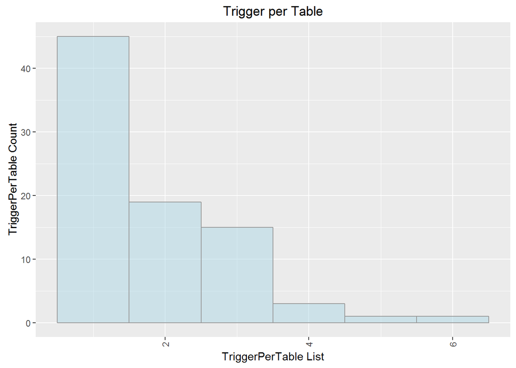

```r
triggersHistogram <- TwoColumnDataFrameToHistogram(aTibble, mainTitle = "Trigger per Table");
triggersHistogram;
```

```r
## Trigger Group Analysis List barplot
triggerGroupBarplot <- DataFrameColumnToBarplot(sqlDataFrame, columnName = "TriggerGroup");
```

```
## Source: local data frame [2 x 2]
##
##   TriggerGroup List TriggerGroup Count
##               <chr>              <int>
## 1      AfterTrigger                119
## 2  InsteadOfTrigger                 32
```

```r
## Trigger Group Analysis List piechart
triggerGroupPiechart <- DataFrameColumnToPiechart(sqlDataFrame, columnName = "TriggerGroup");
```

```
## Source: local data frame [2 x 2]
##
##   TriggerGroup List TriggerGroup Count
##               <chr>              <int>
## 1      AfterTrigger                119
## 2  InsteadOfTrigger                 32
```

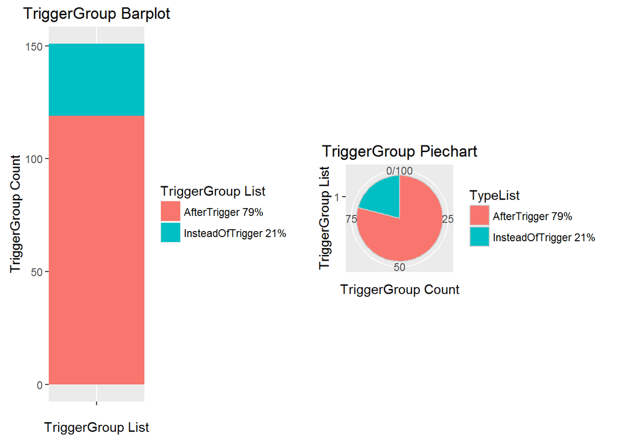

```r
## Trigger Group Analysis List grid
grid.arrange(triggerGroupBarplot, triggerGroupPiechart, nrow = 1, ncol = 2);
```

```r
# Trigger Subgroup After
## Trigger Sub Group After Analysis List barplot
triggerSubgroupBarplot <- DataFrameColumnToBarplot(sqlDataFrame[grepl("^After", sqlDataFrame$TriggerSubgroup), ],
                                                   columnName = "TriggerSubgroup");
```

```
## Source: local data frame [6 x 2]
##
##      TriggerSubgroup List TriggerSubgroup Count
##                     <chr>                 <int>
## 1             AfterDelete                    21
## 2             AfterInsert                    23
## 3             AfterUpdate                    66
## 4       AfterUpdateDelete                     1
## 5 AfterUpdateDeleteInsert                     3
## 6       AfterUpdateInsert                     5
```

```r
## Trigger Sub Group After Analysis List piechart
triggerSubgroupPiechart <- DataFrameColumnToPiechart(sqlDataFrame[grepl("^After", sqlDataFrame$TriggerSubgroup), ],
                                                   columnName = "TriggerSubgroup");
```

```
## Source: local data frame [6 x 2]
##
##      TriggerSubgroup List TriggerSubgroup Count
##                     <chr>                 <int>
## 1             AfterDelete                    21
## 2             AfterInsert                    23
## 3             AfterUpdate                    66
## 4       AfterUpdateDelete                     1
## 5 AfterUpdateDeleteInsert                     3
## 6       AfterUpdateInsert                     5
```

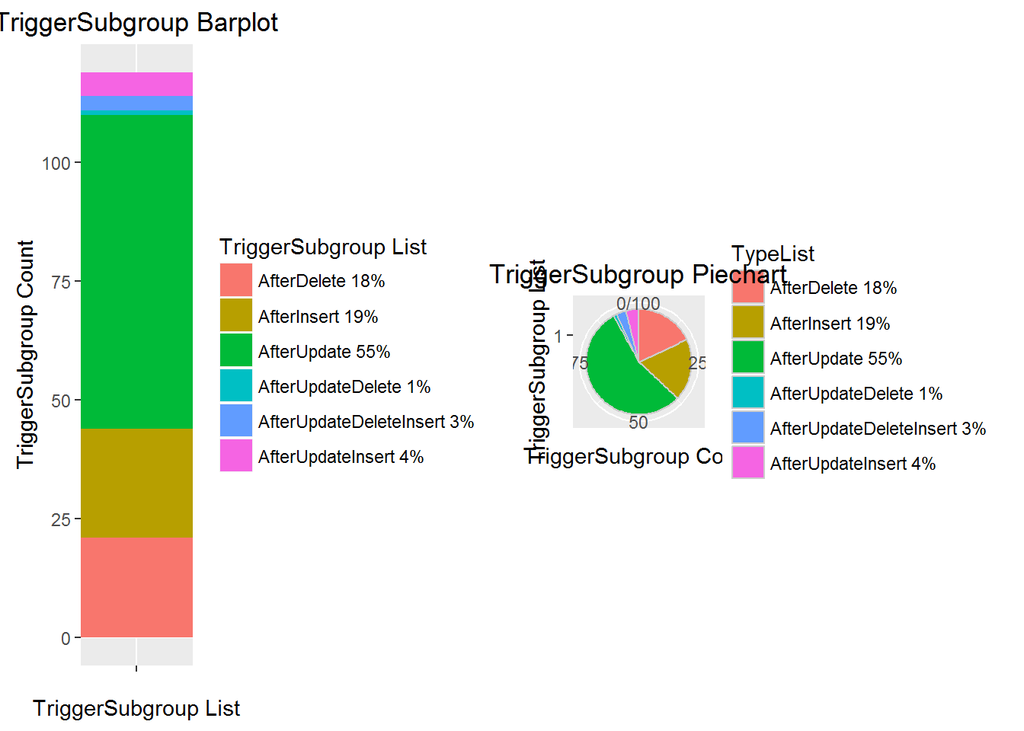

```r
## Trigger Sub Group After Analysis List grid
grid.arrange(triggerSubgroupBarplot, triggerSubgroupPiechart, nrow = 1, ncol = 2);
```

```r
# Trigger Subgroup InsteadOf
## Trigger Sub Group InsteadOf Analysis List barplot
triggerSubgroupBarplot <- DataFrameColumnToBarplot(sqlDataFrame[!grepl("^After", sqlDataFrame$TriggerSubgroup), ],
                                                   columnName = "TriggerSubgroup");
```

```
## Source: local data frame [3 x 2]
##
##   TriggerSubgroup List TriggerSubgroup Count
##                  <chr>                 <int>
## 1      InsteadOfDelete                     3
## 2      InsteadOfInsert                    17
## 3      InsteadOfUpdate                    12
```

```r
## Trigger Sub Group InsteadOf Analysis List piechart
triggerSubgroupPiechart <- DataFrameColumnToPiechart(sqlDataFrame[!grepl("^After", sqlDataFrame$TriggerSubgroup), ],
                                                     columnName = "TriggerSubgroup");
```

```
## Source: local data frame [3 x 2]
##
##   TriggerSubgroup List TriggerSubgroup Count
##                  <chr>                 <int>
## 1      InsteadOfDelete                     3
## 2      InsteadOfInsert                    17
## 3      InsteadOfUpdate                    12
```

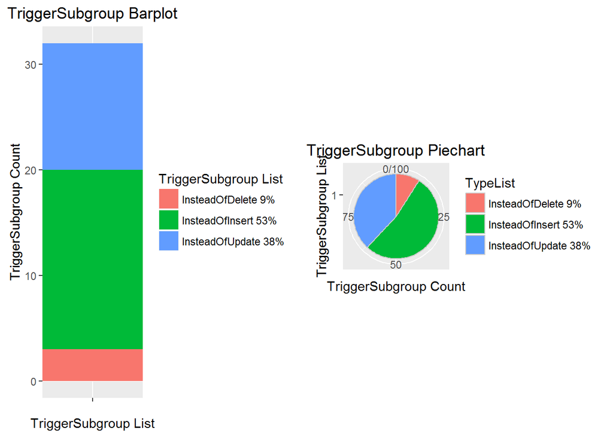

```r
## Trigger Sub Group InsteadOf Analysis List grid
grid.arrange(triggerSubgroupBarplot, triggerSubgroupPiechart, nrow = 1, ncol = 2);
```

```r
# rm()
rm(xlsFile); rm(sqlDataFrame);
rm(aTable); rm(aTibble); rm(triggersHistogram);
rm(triggerGroupBarplot); rm(triggerGroupPiechart);
rm(triggerSubgroupBarplot); rm(triggerSubgroupPiechart);
```